# R Notebook - Childcare Costs

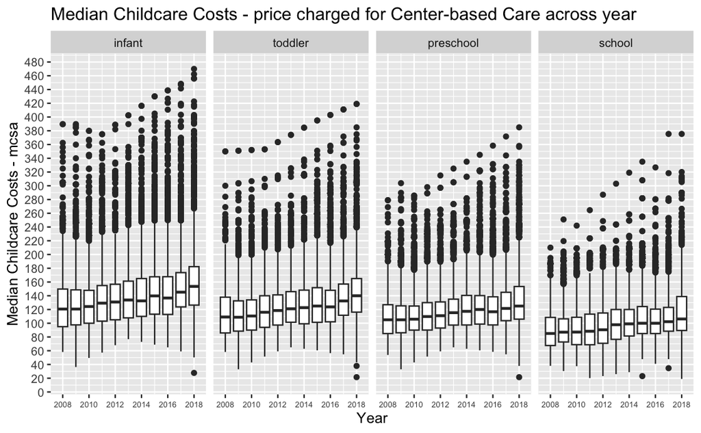

```r
combined_data_for_every_age_group %>%
  ggplot(aes(x = study_year, y = median, group = study_year)) +
  geom_boxplot() +
  labs(title = "Median Childcare Costs - price charged for Center-based Care across year",
       x = "Year",
       y = "Median Childcare Costs - mcsa") +
  scale_x_continuous(breaks = unique(combined_data$study_year)[c(TRUE, FALSE)]) +
  scale_y_continuous(breaks = pretty_breaks(n = 18)) +
  theme(axis.text.x = element_text(size = 6)) +
  facet_wrap(vars(type), nrow = 1)
```

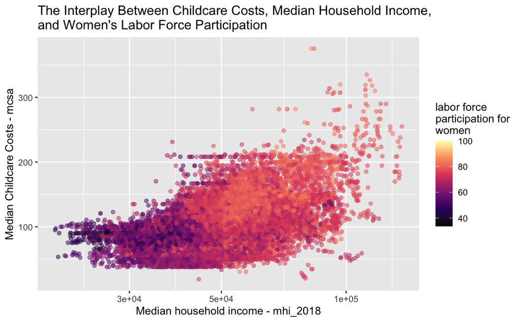

```r
childcare_costs %>%
  ggplot(aes(mhi_2018,mcsa, color = flfpr_20to64)) +
  geom_point(alpha = 0.5) +
  scale_colour_gradientn(colours = viridis_pal(option = "A")(6)) +
  scale_x_log10() +
  labs(title = "The Interplay Between Childcare Costs, Median Household Income,\nand Women's Labor Force Participation",
       x = "Median household income - mhi_2018",
       y = "Median Childcare Costs - mcsa",
       color = "labor force\nparticipation for\nwomen"
  )
```

As we can see above, for counties with higher household income women’s labor force participation is higher. Also, childcare costs are higher for high median household income counties. It does seem to be with lower income county women deciding to stay home and taking care of children instead of returning on labor market. At scatter plot below, I’ve decided to check this thesis.

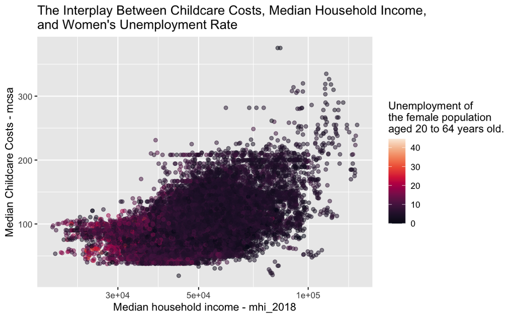

```r
childcare_costs %>%
  ggplot(aes(mhi_2018,mcsa, color = funr_20to64)) +
  geom_point(alpha = 0.5) +
  scale_colour_gradientn(colours = viridis_pal(option = "F")(10)) +
  scale_x_log10() +
  labs(title = "The Interplay Between Childcare Costs, Median Household Income,\nand Women's Unemployment Rate",
       x = "Median household income - mhi_2018",
       y = "Median Childcare Costs - mcsa",
       color = "Unemployment of\nthe female population\naged 20 to 64 years old."
  )
```

As we could expect, in counties with lower income household unemployment rate for women at working age is higher than for counties with higher median household income. In counties with high median householde income unemployment rate is close to 0, when for Lower-income counties the rate is much higher, up to over 40. Here could be a few possible explanations:

1. Limited Job Opportunities - This scarcity of employment options can make it more challenging for women to find suitable job that is compatible with caring for children, leading to higher unemployment rates.
2. Lack of possibility for raising the qualifications - Lower-income counties may face educational and skill gaps among their population. Women in these areas might have limited access to quality education and training programs, which can hinder their employability and increase their unemployment rates.

```r
glimpse(s)
```

```
Rows: 34,567
Columns: 64
$ county_fips_code          <dbl> 1001, 1001, 1001, 1001, 1001, 1001, 1001, 1001, 1001, 1001, 1…
$ study_year                <dbl> 2008, 2009, 2010, 2011, 2012, 2013, 2014, 2015, 2016, 2017, 2…
$ unr_16                    <dbl> 5.42, 5.93, 6.21, 7.55, 8.60, 9.39, 8.50, 7.64, 5.59, 5.21, 4…
$ funr_16                   <dbl> 4.41, 5.72, 5.57, 8.13, 8.88, 10.31, 9.18, 8.45, 6.27, 5.84, …
$ munr_16                   <dbl> 6.32, 6.11, 6.78, 7.03, 8.29, 8.56, 7.95, 6.91, 4.99, 4.64, 4…
$ unr_20to64                <dbl> 4.6, 4.8, 5.1, 6.2, 6.7, 7.3, 6.8, 5.9, 4.4, 4.6, 3.9, 3.8, 4…
$ funr_20to64               <dbl> 3.5, 4.6, 4.6, 6.3, 6.4, 7.6, 6.8, 6.1, 4.6, 4.9, 3.0, 3.5, 4…
$ munr_20to64               <dbl> 5.6, 5.0, 5.6, 6.1, 7.0, 7.0, 6.8, 5.9, 4.3, 4.3, 4.7, 4.1, 4…
$ flfpr_20to64              <dbl> 68.9, 70.8, 71.3, 70.2, 70.6, 70.7, 69.9, 68.8, 68.3, 67.9, 6…
$ flfpr_20to64_under6       <dbl> 66.9, 63.7, 67.0, 66.5, 67.1, 67.5, 65.2, 66.8, 67.4, 63.9, 7…
$ flfpr_20to64_6to17        <dbl> 79.59, 78.41, 78.15, 77.62, 76.31, 75.91, 75.13, 74.60, 72.60…
$ flfpr_20to64_under6_6to17 <dbl> 60.81, 59.91, 59.71, 59.31, 58.30, 58.00, 57.40, 57.00, 53.30…
$ mlfpr_20to64              <dbl> 84.0, 86.2, 85.8, 85.7, 85.7, 85.0, 84.2, 82.5, 81.9, 82.0, 8…
```

[output cut: 51 more lines]